# Analyse Factorielle des Correspondances

Marie-Pierre Etienne

marie-pierre.etienne@ensai.fr

ENSAI - CREST

https://marieetienne.github.io/MAF/

2026-11-16

# Introduction

## Les manchots comme exemple introductif

L’étude sur les manchots de Palmer s’intéresse à diverses espèces de manchots sur diverses îles.

Question : est ce que les différentes espèces sont présentes de la même manière sur les différentes îles ?

| island | Adelie | Chinstrap | Gentoo |
| --- | --- | --- | --- |
| Biscoe | 44 | 0 | 119 |
| Dream | 55 | 68 | 0 |
| Torgersen | 47 | 0 | 0 |

Avec peu d’espèces, et peu d’îles, il est facile de constater que les espèces ne sont pas présentes de la même manière sur toutes les îles.

Conclusion : Il y a un lien entre espèce et île où le manchot est observé.

## Exemple causes de décès en France

Le fichier des décès en France contient pour 65 causes de décès le nombre cumulés de morts en 1979 et 2006 par tranche d’age, puis dans Les 65 lignes suivantes uniquement ce cumul pour 1979, puis pour 2006 et enfin pour chaque année le nombre de décès par tranche d’ages, toutes causes confondues.

| Cause | X0.1 | X1.4 | X5.14 | X15.24 | X25.34 | X35.44 | X45.54 | X55.64 | X65.74 | X75.84 | X85.94 | X95.et.plus |
| --- | --- | --- | --- | --- | --- | --- | --- | --- | --- | --- | --- | --- |
| Abus alcool et psychose alcoolique | 0 | 0 | 0 | 29 | 214 | 763 | 1,839 | 1,543 | 1,203 | 636 | 95 | 5 |
| Accidents de transport | 52 | 194 | 655 | 4,653 | 2,451 | 1,841 | 1,927 | 1,409 | 1,479 | 1,211 | 272 | 12 |
| Arthrite rhumatoïde et ostéoarthrite | 0 | 0 | 3 | 2 | 6 | 6 | 26 | 59 | 301 | 526 | 301 | 57 |
| Asthme | 9 | 6 | 9 | 29 | 39 | 59 | 183 | 266 | 535 | 846 | 464 | 67 |
| Autres accidents | 646 | 427 | 535 | 1,685 | 1,431 | 1,464 | 2,253 | 2,219 | 3,153 | 5,110 | 4,734 | 1,304 |
| Autres cardiopathies | 104 | 62 | 77 | 186 | 359 | 792 | 2,335 | 4,296 | 13,370 | 34,834 | 33,671 | 7,454 |

Objectif : Etude de la liaison entre age et cause de décès..

Les tranches d’âge sont définies a priori pour représenter des causes de décès similaires.

## Cadre général

L’analyse factorielle des correspondances (AFC) est une méthode factorielle pour l’exploration statistique d’une table de contingence définie par deux variables qualitatives.

Objectif : Le but est d’étudier la liaison entre ces deux variables qualitatives(notamment quelles associations de modalités sont sur-représentées).

**Note**

La terminologie analyse des correspondances vient du fait que l’on analyse un tableau mettant en correspondance deux ensembles:

- L’ensemble des lignes du tableau,
- et l’ensemble des colonnes du tableau.

## Les données

- Les données brutes
- Le tableau disjonctif complet
- La table de contingence

On considère deux variables qualitatives $A$ et $B$ ayant respectivement $I$ ( $a_1, \ldots, a_I$) et $J$ ( $b_1, \ldots, b_J$) modalités. Ces variables sont observées simultanément sur $n$ individus affectés de poids identiques $1/n$.

Les données se présentent initialement sous la forme d’un tableau à $n$ lignes et 2 (ou 3 colonnes si on ajoute un identifiant).

**Exemple de table de données**

| ID | A | B |
| --- | --- | --- |
| 001 | $a_1$ | $b_2$ |
| 002 | $a_1$ | $b_2$ |
| 003 | $a_2$ | $b_2$ |
| 004 | $a_2$ | $b_1$ |
| 005 | $a_1$ | $b_1$ |
| 005 | $a_1$ | $b_3$ |

Il est fréquent de recoder (ou même de récolter) les variables sous la forme d’un tableau disjoinctif complet. A chaque variable $\ell$, on associe une table $X^{\ell},$ à $n$ et autant de colonnes que la variable $\ell$, qui contient pour chaque individu $k,$ à la colonne $m$ un $1$ si l’individu $k$ possède la modalité $m$ et un $0$ sinon.

**Sur l’exemple précédent**

$$\bf{X} =\begin{pmatrix} \class{orange}{X^{1}} & \class{rouge}{X^{2}} \end{pmatrix}$$
$$\bf{X} = \overset{{\begin{matrix} \class{orange}{a_1} & \class{orange}{a_2} & \class{rouge}{b_1} & \class{rouge}{b_2} & \class{rouge}{b_3}\end{matrix}}}{
\begin{pmatrix}
\class{orange}{1} & \class{orange}{0} & \class{rouge}{0} & \class{rouge}{1} & \class{rouge}{0}\\
\class{orange}{1} & \class{orange}{0} & \class{rouge}{0} & \class{rouge}{1} & \class{rouge}{0}\\
\class{orange}{0} & \class{orange}{1} & \class{rouge}{0} & \class{rouge}{1} & \class{rouge}{0}\\
\class{orange}{0} & \class{orange}{1} & \class{rouge}{1} & \class{rouge}{0} & \class{rouge}{0}\\
\class{orange}{1} & \class{orange}{0} & \class{rouge}{1} & \class{rouge}{0} & \class{rouge}{0}\\
\class{orange}{1} & \class{orange}{0} & \class{rouge}{0} & \class{rouge}{0} & \class{rouge}{1}\\
\end{pmatrix}}$$

Il s’agit de la matrice $K$ à $I$ lignes et $J$ colonnes, dont le terme général $k_{ij}$ compte le nombre d’individus possédant simultanément les carcatéristiques $a_i$ et $b_j$.

$$\class{vert}{K}=\begin{bmatrix}
\class{vert}{k_{ij}}
\end{bmatrix}_{\begin{array}{r}
i=1,\ldots,I\\
j=1,\ldots,J
\end{array}}.$$

**Remarque 1**

$$\class{vert}{K} = (\class{orange}{X^1})^\top \class{rouge}{X^2}$$

**Remarque 2**

$${\boldsymbol{X}}^\top {\boldsymbol{X}}= \begin{pmatrix} \class{orange}{C_1} & \class{vert}{K} \\ \class{vert}{K^\top} & \class{rouge}{C_2}\end{pmatrix},$$
$C_{\ell}$ une matrice diagonale, dont la diagonale est le nombre d’observations dans chaque modalité.

**Sur l’exemple précédent**

$$\class{vert}{K} = \begin{pmatrix}
\class{vert}{1} & \class{vert}{2} & \class{vert}{1} \\
\class{vert}{1} & \class{vert}{1} & \class{vert}{0} \\
\end{pmatrix}$$

$${\boldsymbol{X}}^\top {\boldsymbol{X}}=
\begin{pmatrix}
\class{orange}{4} & 0 & \class{vert}{1} & \class{vert}{2} & \class{vert}{1} \\
0 & \class{orange}{2} & \class{vert}{1} & \class{vert}{1} & \class{vert}{0} \\
\class{vert}{1} & \class{vert}{1} & \class{rouge}{2} & 0 & 0 \\
\class{vert}{2} & \class{vert}{1} & 0 & \class{rouge}{3} & 0 \\
\class{vert}{1} & \class{vert}{0} & 0 & 0 & \class{rouge}{1} \\
\end{pmatrix}$$

## Quelques notations

### Formellement

On note les effectifs

- $k_{\class{orange}{i+}} = \sum_{\class{rouge}{j=1}}^{\class{rouge}{J}} k_{ij}$ le nombre total d’individus ayant la modalité $\class{orange}{i}$
- $k_{\class{rouge}{+j}} = \sum_{\class{orange}{i=1}}^{\class{orange}{I}} k_{ij}$ le nombre total d’individus ayant la modalité $\class{rouge}{j}$
- $n = \sum_{\class{orange}{i=1}}^{\class{orange}{I}}\sum_{\class{rouge}{j=1}}^{\class{rouge}{J}} k_{ij}$
- les proportions $f_{ij} = k_{ij}/n,$

Et les proportions marginales

- $f_{\class{orange}{i+}} = \sum_{\class{rouge}{j=1}}^{\class{rouge}{J}} f_{ij}$ la proportion d’individus ayant la modalité $\class{orange}{i}$
- $f_{\class{rouge}{+j}} = \sum_{\class{orange}{i=1}}^{\class{orange}{I}} f_{ij}$ la proportion d’individus ayant la modalité $\class{rouge}{j}$
- $f_{++}= 1$

### Sur l’exemple

$$\class{vert}{K} = \begin{array}{ccc||c}
&& & Eff. marg\\
\class{vert}{1=k_{11}} & \class{vert}{2=k_{12}} & \class{vert}{1=k_{13}} & 4 = k_{1+}\\
\class{vert}{1=k_{21}} & \class{vert}{1=k_{22}} & \class{vert}{0=k_{23}} & 2 = k_{2+}\\ \hline
2 = k_{+1} & 3 = k_{+2} & 1 = k_{+3} & 6 = n\\
\end{array}$$

## Modèle d’indépendance

On dit que deux variables $A$ et $B$ sont non liées si et seulement si
$$\forall (i,j)\in\{1,\ldots,I\}\times\{1,\ldots,J\}: \; k_{ij}=\frac{k_{i +} k_{+ j}}{n}$$

Cette notion est bien sûr liée à l’indépendance en probabilité. En effet, deux variables aléatoires $A$ et $B$ sont indépendantes ssi

$$\begin{align*} \underbrace{\mathbb{P}(A=i \cap B=j)}_{\text{estimée par } \frac{k_{ij}}{n}= f_{ij}} = \underbrace{\mathbb{P}(A=i)}_{\text{estimée par} \frac{k_{i +}}{n} = f_{i +}} \times \underbrace{\mathbb{P}(B=j)}_{\text{estimée par} \frac{k_{+ j}}{n}=f_{+j}}, \forall (i,j)\;
\end{align*}$$

On souhaite étudier la liaison entre $A$ et $B$ à partir de nos observations.

La représentation graphique des profils-lignes ou des profils-colonnes, au moyen de diagrammes en barres parallèles, ainsi que le calcul de coefficients de liaison (Cramer) donnent une première idée de la variation conjointe des deux variables.

Le test du $\chi^2$ permet de plus de s’assurer du caractère significatif de cette liaison.

## Test d’indépendance du $\chi^2$

*(cf cours sur les tests du 2d semestre)*

- l’hypothèse nulle est $H_0$: $A$ et $B$ sont indépendantes,
- l’hypothèse alternative est $H_1$: $A$ et $B$ ne sont pas indépendantes.

La statistique de test est
$$T = \sum_{i=1}^{I} \sum_{j=1}^{J} \frac{\left(\text{Effectif observé}_{ij} - \text{Effectif ettendu}_{ij} \right)^2}{\text{Effectif attendu}_{ij} } = \sum_{i=1}^{I} \sum_{j=1}^{J} \frac{( n f_{ij} - n f_{i+ } f_{ +j})^2}{n f_{i+} f_{+j}}= n \class{bleu}{\sum_{i=1}^{I} \sum_{j=1}^{J} \frac{( f_{ij} - f_{i+ } f_{ +j})^2}{f_{i+} f_{+j}}} = n \class{bleu}{\Phi^2} .$$

Pour des grandes valeurs de $n$, et si $H_0$ est vraie,
$$T \sim \chi^2_{(I-1)(J-1)}.$$

Si $T$ est grand, on rejette $H_0$.

La force de la dépendance est capturée par $\class{bleu}{\Phi^2}$

## Probabilité conditionnelle

### Rappel

$$P(A=i\vert B= j) = \frac{P(A=i, B= j)}{P(B= j)}$$

### Déclinaison sur les fréquences

- $\frac{f_{ij}}{f_{i+}}$ est la fréquence d’apparition de la modalité $j$ au sein de la population $A=i$. Si $A$ et $B$ sont indépendantes, alors $\frac{f_{ij}}{f_{i+}}= f_{+j}$
- $\frac{f_{ij}}{f_{+j}}$ est la fréquence d’apparition de la modalité $i$au sein de la population $B=j$. Si $A$ et $B$ sont indépendantes, alors $\frac{f_{ij}}{f_{+j}}= f_{i+}$

# Profils-lignes et profils-colonnes

## Profils-lignes $N_I$

Le tableau des profils-lignes $X$ est le tableau des fréquences conditionnelles de la modalité $j$ de $B$ sachant la modalité $i$ de $A$:

- Les points
- Les poids
- La métrique

$$X=\begin{pmatrix}
\frac{f_{ij}}{f_{i+}}
\end{pmatrix}_{\begin{array}{r}
i=1,\ldots,I\\
j=1,\ldots,J
\end{array}}$$

Ainsi avec les notations du cours d’ACP
$$X = \begin{pmatrix}
x_1^\top\\
\vdots\\
x_i^\top\\
\vdots\\
x_I^\top\\
\end{pmatrix}
\text{ avec }
x_i = \begin{pmatrix}
f_{i1}/f_{i+}\\
\vdots\\
f_{ij}/f_{i+}\\
\vdots\\
f_{iJ}/f_{i+}\\
\end{pmatrix}\in\mathbb{R}^J.$$

A chaque ligne $i$, on fait correspondre un point dans ${\mathbb{R}}^J$ dont la j$^\text{ème}$ coordonnée vaut $f_{ij}/f_{i+}$.

Chaque point $i$ est affecté du poids $f_{i+}.$

Le point moyen $G_I$ est défini par

$$G_I = \sum_{i=1}^I f_{i+} x_i = (f_{+1}, \ldots, f_{+J})$$
On a le nuage de points $X$, complété par les poids $f_{i+}.$

La distance dont on munit l’espace ${\mathbb{R}}^J$ consiste à donner un poids $1/f_{+j}$ à la j$^\text{ème}$ dimension, la distance au carré (dite distance du $\chi^2$) entre les points $i_1$ et $i_2$ est définie par

$$d_{\chi^2}^2(x_{i_1}, x_{i_2}) = \sum_{j=1}^J \frac{1}{f_{+j}}\left (\frac{f_{i_1j}}{f_{i_1+}} -\frac{f_{i_2j}}{f_{i_2+}} \right)^2$$

Ce choix est motivé par l’inertie du point $x_i$ par rapport au centre de garivité $G_I$, en effet

$$Inertie_{G_I}(x_i) = f_{i+} d_{\chi^2}^2(x_{i}, G_I) = f_{i+} \sum_{j=1}^J \frac{1}{f_{+j}}\left (\frac{f_{ij}}{f_{i+}} -f_{+j} \right)^2= \sum_{j=1}^J \frac{\left ( f_{ij} - f_{i+}f_{+j} \right)^2 }{f_{i+} f_{+j}}.$$

Ainsi l’inertie totale du nuage par rapport à $G_I$ vaut

$$I_{G_I} = \sum_{i=1}^I \sum_{j=1}^J \frac{\left ( f_{ij} - f_{i+}f_{+j} \right)^2 }{f_{i+} f_{+j}} = \Phi^2$$
L’inertie mesure l’écart à l’indépendance. L’étude du nuage $N_I$ rend compte de la structure des données.

## Profils-colonnes

Dans le tableau de contingence, lignes et colonnes jouent des rôles symétriques

Le tableau des profils-colonnes $X$ est le tableau des fréquences conditionnelles de la modalité $i$ de $A$ sachant la modalité $j$ de $B$:

- Les points
- Les poids
- La métrique

$$X=\begin{pmatrix}
\frac{f_{ij}}{f_{+j}}
\end{pmatrix}_{\begin{array}{r}
i=1,\ldots,I\\
j=1,\ldots,J
\end{array}}$$

Ainsi avec les notations du cours d’ACP
$$X = \begin{pmatrix}
x^1 & \ldots & x^j & \ldots & x^J
\end{pmatrix}
\text{ avec }
x^j = \begin{pmatrix}
f_{1j}/f_{+j}\\
\vdots\\
f_{ij}/f_{+j}\\
\vdots\\
f_{Ij}/f_{+j}\\
\end{pmatrix}\in\mathbb{R}^I.$$

A chaque colonne $j$, on fait correspondre un point dans ${\mathbb{R}}^I$ dont la i$^\text{ème}$ coordonnée vaut $f_{ij}/f_{+j}$.

Chaque point $j$ est affecté du poids $f_{+j}.$

Le point moyen $G_J$ est défini par

$$G_J = \sum_{j=1}^J f_{+j}\, x^j = (f_{1+}, \ldots, f_{I+})$$
On a le nuage de points $X$, complété par les poids $f_{+j}.$

La distance dont on munit l’espace ${\mathbb{R}}^I$ consiste à donner un poids $1/f_{i+}$ à la i$^\text{ème}$ dimension, la distance au carré (dite distance du $\chi^2$) entre les points $j_1$ et $j_2$ est définie par

$$I_{G_J}(x^j) = f_{+j} d_{\chi^2}^2(x^{j}, G_J) = f_{+j} \sum_{i=1}^I \frac{1}{f_{i+}}\left (\frac{f_{ij}}{f_{+j}} -f_{i+} \right)^2= \sum_{i=1}^I \frac{\left ( f_{ij} - f_{i+}f_{+j} \right)^2 }{f_{i+} f_{+j}}.$$

Ainsi l’inertie totale du nuage par rapport à $G_I$ vaut

$$I_{G_J} = \sum_{i=1}^I \sum_{j=1}^J \frac{\left ( f_{ij} - f_{i+}f_{+j} \right)^2 }{f_{i+} f_{+j}} = \Phi^2$$

L’inertie mesure l’écart à l’indépendance. L’étude du nuage $N_J$ rend compte de la structure des données.

## ACP des nuages lignes et colonnes

- ACP de $N_I$
- ACP de $N_J$
- Nombre d’axes

Réalisé une l’ACP profils lignes.

- L’origine des axes est placée au centre $G_I$ du nuage $N_I$
- On recherche une suite d’axes othogonaux d’inertie maximale
- Le nuage est projeté sur ces axes et on représente ces projections en associant deux axes pour créer un plan.
- la proximité entre deux profils lignes, s’exprime par la même manière de s’écarter de l’indépendance.

Réalisé une l’ACP profils colonnes

- L’origine des axes est placée au centre $G_J$ du nuage $N_J$
- On recherche une suite d’axes othogonaux d’inertie maximale
- Le nuage est projeté sur ces axes et on représente ces projections en associant deux axes pour créer un plan.
- la proximité entre deux profiils colonne, s’exprime par la même manière de s’écarter de l’indépendance.

Puisque le nuage $N_I$ se place dans l’espace ${\mathbb{R}}^J$, on peut penser qu’il faut $J$ axes pour tout représenter. Mais

- La somme des coordonnées d’un profil vaut 1, on est donc dans un espace de dimension ${\mathbb{R}}^{J-1}$
- Le nuage $N_I$ centré comporte $I$ lignes, il est possible de les représenter tous avec $I-1$ dimensions

On représente donc toute l’information avec $\min(I-1, J-1)$ axes.

## Représentation

- Représentation des profils lignes
- Représentation des profils colonnes

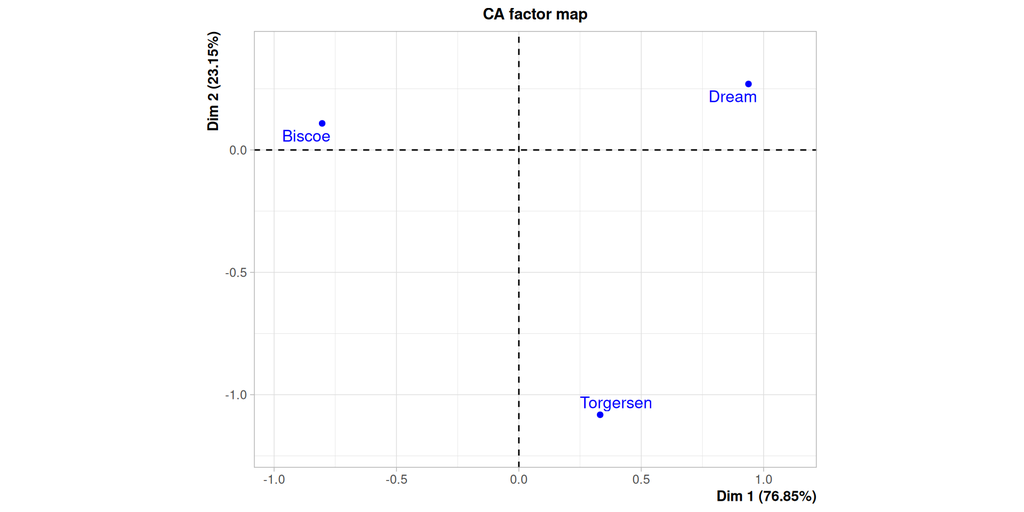

```r
penguins.CA <- CA(penguin_cont, graph = FALSE)
plot(penguins.CA, invisible = "col" )
```

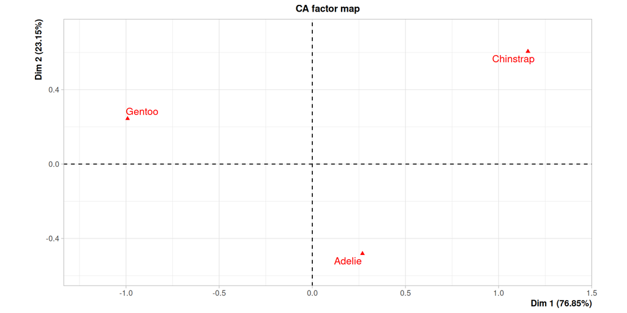

```r
plot(penguins.CA, invisible = "row" )
```

## Représentation jointe lignes et colonnes

- Remarques
- Visualisation
- Les deux nuages $N_I$ et $N_J$ ont la même inertie
- L’inertie projetée sur l’axe $\ell$ est données par l’inertie du nuage projeté sur cet axe.
  - concernant les profils lignes $\sum_{i}^I f_{i+} \lVert OH_i^{\ell}\rVert^2 = \lambda_{\ell}$
  - concernant les profils colonnes $\sum_{j}^J f_{+j} \lVert OH_j^{\ell}\rVert^2 = \lambda_{\ell}$ Ainsi les deux nuages ont la même inertie projetée sur chaque axe.
- Lien entre coordonnées des lignes et des colonnes : relations pseudo-barycentriques suivantes pour $\ell=1,\ldots,min(I-1, J-I)$

$$F_{\ell}(i) =\frac{1}{\sqrt{\lambda_{\ell}}} \sum_{j=1}^J \frac{f_{ij}}{f_{i+}} G_{\ell(j)},$$
$$G_{\ell}(j) =\frac{1}{\sqrt{\lambda_{\ell}}} \sum_{i=1}^I \frac{f_{ij}}{f_{+j}} F_{\ell(i)},$$

où $F_{\ell}(i)$ désigne la coordonnée de la ligne $i$ sur l’axe $\ell$, tandis que $G_{\ell}(j)$ désigne la coordonnée de la colonne $j$ sur l’axe $\ell$.

On peut donc représenter lignes et colonnes sur la même projection.

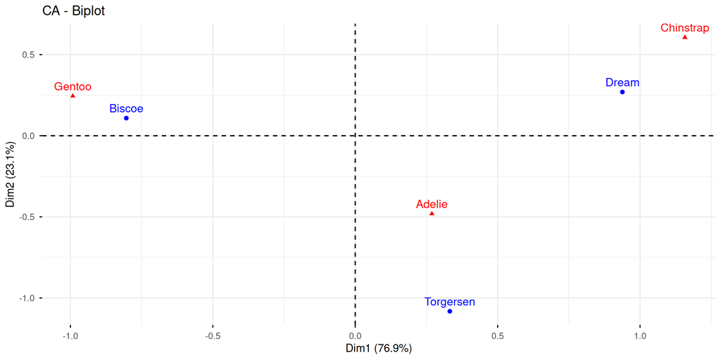

```r
fviz_ca(penguins.CA)
```

```r
penguin_cont |> rownames_to_column(var = 'island') |>
  flextable()
```

| island | Adelie | Chinstrap | Gentoo |
| --- | --- | --- | --- |
| Biscoe | 44 | 0 | 119 |
| Dream | 55 | 68 | 0 |
| Torgersen | 47 | 0 | 0 |

## Interprétation jointe lignes et colonnes

Puisque l’origine du repère est confondue avec le barycentre des nuages.

- Si un profil ligne a une coordonnée positive sur un axe, il s’associe
  - plus que dans le modèle d’indépendance aux modalités $j$ ayant une coordonnées positive
  - moins que dans le modèle d’indépendance aux modalités $j$ ayant une coordonnées négative

## Inerties associés aux axes

En AFC, l’inertie a un sens particulier.

En effet, si on considère la projection de $N_I$ sur l’axe $\ell$.

- Si on place chaque profil colonne $G_{\ell}(j)$ à l’exact barycentre, alors $N_J$ est au centre du nuage $N_I$ et donc $N_I$ ne peut-être un nuage de barycentre de $N_J$.
- C’est la valeur $\lambda_{\ell}$ qui dilate les barycentres de $1/\sqrt{\lambda_{\ell}}$ et donc $\lambda_{\ell}\leq 1$.

La valeur propre $1$ signifie que donc une association parfaite entre ligne et colonnes.

```r
penguins.CA$eig[,1]
```

```
    dim 1     dim 2
0.6568035 0.1978211
```

## Qualité de la représentation

### Qualité de la représentation d’un profil ligne $i$

La qualité de la réprésentation de l’individu $i$ sur l’axe $\ell$ est donné par
$$Qual_{\ell}(i) = \frac{\text{inertie de }i\text{ projeté sur }\ell}{\text{inertie de } i}= \frac{(OH_i^{\ell)^2}}{(Oi)^2}$$

### Contribution d’un profil $i$ à l’inertie d’un axe

$$Cont_{\ell}(i) = \frac{\text{inertie de }i\text{ projeté sur }\ell}{\text{inertie de } N_{I}\text{ projeté sur }\ell }= \frac{f_{i+}(OH_i^{\ell)^2}}{\lambda_{\ell}}$$

# Etude des décès en France

## Statistiques descriptives

Le fichier présente pour chaque tranche d’âge

- 65 lignes présentant le cumul de décès par cause en 1979 et 2006
- 65 lignes présentant le cumul de décès par cause en 2006
- 64 lignes présentant le cumul de décès par cause en 1979 (le SIDA n’est pas pris en compte)
- 28 lignes présentant le cumul de décès toutes causes confondues cause en 1979 à 2006.

```r
deces_dta <- read.table("http://factominer.free.fr/livreV2/deces.csv", header = TRUE, sep = ";",
                        check.names = TRUE, fileEncoding = "latin1") |>
  rename(Cause = X) |>
  column_to_rownames(var = "Cause")
deces_dta <- deces_dta |> rownames_to_column("Cause") |>
  mutate(Periode = case_when(
    str_detect(Cause, pattern = "^[70][0-9]_") ~ str_extract(Cause, pattern = "^[70][0-9]"),
    str_detect(Cause, pattern = "^[12]+") ~ "Deces_annuel",
    str_detect(Cause, pattern = "^[0-9]+", negate = TRUE) ~ "Deces_1979et2006",
    TRUE ~ NA_character_ # valeur par defaut
  ))

deces_dta |>
  group_by(Periode) |>
  count()
dim(deces_dta)

# effectifs lignes
deces_dta |>
  filter(Periode == "Deces_1979et2006") |>
  mutate(k_i_plus = rowSums(across(where(is.numeric))) ) |>
  select(k_i_plus) |> head()
# effectifs colonnes
deces_dta |>
  filter(Periode == "Deces_1979et2006") |>
  select(-Periode) |>
  column_to_rownames("Cause") |>
  summarise_all(sum)
```

```
# A tibble: 4 × 2
# Groups:   Periode [4]
  Periode              n
  <chr>            <int>
1 06                  65
2 79                  64
3 Deces_1979et2006    65
4 Deces_annuel        28
[1] 222  14
  k_i_plus
1     6327
2    16156
3     1287
4     2512
5    24961
6    97540
   X0.1 X1.4 X5.14 X15.24 X25.34 X35.44 X45.54 X55.64 X65.74 X75.84 X85.94
1 10429 2226  3395  12431  14758  26600  69546 105126 200976 337313 231583
  X95.et.plus
1       43374
```

## Test d’indépendance

### Test sur toutes les données

```r
deces_dta |> select(-Periode) |>
  column_to_rownames("Cause") |> chisq.test()
```

```
    Pearson's Chi-squared test

data:  column_to_rownames(select(deces_dta, -Periode), "Cause")
X-squared = 2695798, df = 2431, p-value < 2.2e-16
```

### Test sur les données actives

```r
deces_dta |>
  filter(Periode == "Deces_1979et2006") |>
  select(-Periode) |>
  column_to_rownames("Cause") |> chisq.test()
```

```
    Pearson's Chi-squared test

data:  column_to_rownames(select(filter(deces_dta, Periode == "Deces_1979et2006"),     -Periode), "Cause")
X-squared = 1080254, df = 704, p-value < 2.2e-16
```

## Analyse factorielle des correspondances (AFC)

### Calcul et résumé de l’AFC

```r
deces_dta <- deces_dta |>
  column_to_rownames("Cause") |>
  select(-Periode)
res.ca <- CA(deces_dta, row.sup = 66:nrow(deces_dta), ncp = 25,
             graph = FALSE)
summary(res.ca, nb.dec = 4)
```

```
Call:
CA(X = deces_dta, ncp = 25, row.sup = 66:nrow(deces_dta), graph = FALSE)

The chi square of independence between the two variables is equal to 1080254 (p-value =  0 ).

Eigenvalues
                        Dim.1    Dim.2    Dim.3    Dim.4    Dim.5    Dim.6
Variance               0.5505   0.2570   0.1385   0.0338   0.0199   0.0143
% of var.             53.9002  25.1628  13.5653   3.3141   1.9439   1.4022
Cumulative % of var.  53.9002  79.0630  92.6283  95.9424  97.8863  99.2885
                        Dim.7    Dim.8    Dim.9   Dim.10   Dim.11
Variance               0.0037   0.0017   0.0013   0.0004   0.0001
% of var.              0.3665   0.1624   0.1256   0.0439   0.0132
Cumulative % of var.  99.6550  99.8174  99.9430  99.9868 100.0000

Rows (the 10 first)

Abus alcool et psychose alcoolique                                    |
Accidents de transport                                                |
Arthrite rhumatoïde et ostéoarthrite                                  |
Asthme                                                                |
Autres accidents                                                      |
Autres cardiopathies                                                  |
Autres causes externes de blessure et empoisonnement                  |
Autres maladie appareil circulatoire                                  |
Autres maladies chroniques voies respiratoires inférieures            |
Autres maladies appareil digestif                                     |
                                                                      Iner*1000
Abus alcool et psychose alcoolique                                      10.5781
Accidents de transport                                                 139.9313
Arthrite rhumatoïde et ostéoarthrite                                     0.1716
Asthme                                                                   0.0468
Autres accidents                                                        17.9324
Autres cardiopathies                                                    20.1181
Autres causes externes de blessure et empoisonnement                     0.0647
Autres maladie appareil circulatoire                                     4.9198
Autres maladies chroniques voies respiratoires inférieures               1.7971
Autres maladies appareil digestif                                        1.0660

Abus alcool et psychose alcoolique                                    |
```

[output cut: 361 more lines]

```
06_Autres causes externes de blessure et empoisonnement                0.0776
06_Autres maladie appareil circulatoire                                0.2516
06_Autres maladies chroniques voies respiratoires inférieures          0.1652
06_Autres maladies appareil digestif                                   0.2177
                                                                         cos2
06_Abus alcool et psychose alcoolique                                  0.3297 |
06_Accidents de transport                                              0.1673 |
06_Arthrite rhumatoïde et ostéoarthrite                                0.2737 |
06_Asthme                                                              0.1362 |
06_Autres accidents                                                    0.4490 |
06_Autres cardiopathies                                                0.3712 |
06_Autres causes externes de blessure et empoisonnement                0.1918 |
06_Autres maladie appareil circulatoire                                0.2999 |
06_Autres maladies chroniques voies respiratoires inférieures          0.1650 |
06_Autres maladies appareil digestif                                   0.2895 |
```

## AFC - Marges

### Marges des colonnes et lignes

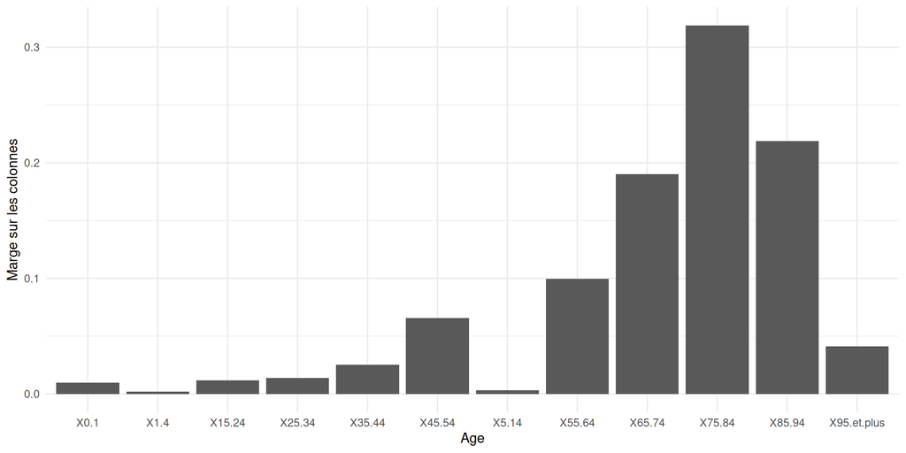

```r
round(res.ca$call$marge.col, 3)
round(res.ca$call$marge.row[order(res.ca$call$marge.row)], 3)

tibble(marge_col = res.ca$call$marge.col, Age = colnames(deces_dta))  |> ggplot() +  aes(x=Age, y =marge_col ) +
  geom_bar(stat="identity") + ylab("Marge sur les colonnes")
```

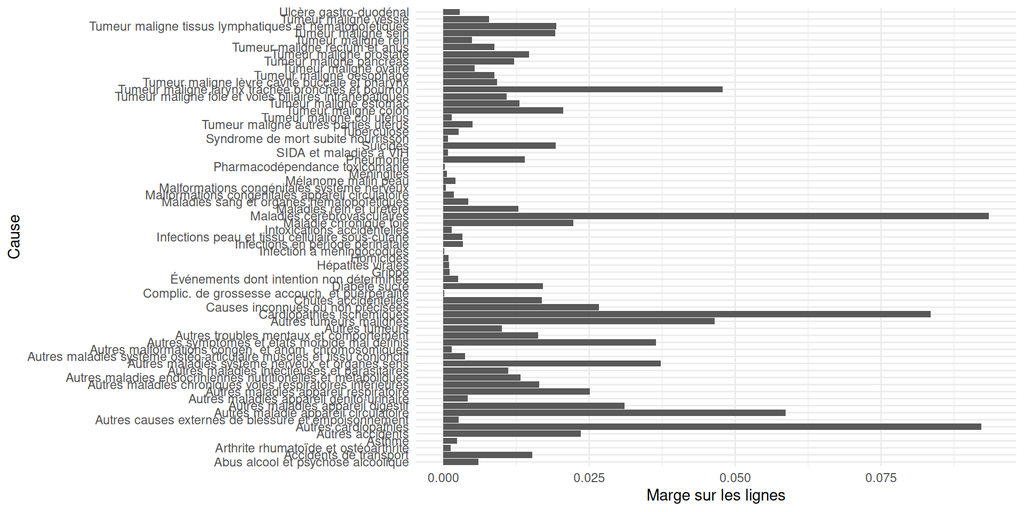

[output not shown]

[output cut: 79 more lines]

```
                                                                0.036
                      Autres maladies système nerveux et organes sens
                                                                0.037
                                              Autres tumeurs malignes
                                                                0.046
                     Tumeur maligne larynx trachée bronches et poumon
                                                                0.048
                                 Autres maladie appareil circulatoire
                                                                0.059
                                            Cardiopathies ischémiques
                                                                0.084
                                                 Autres cardiopathies
                                                                0.092
                                          Maladies cérébrovasculaires
                                                                0.093
```

```r
tibble(marge_row = res.ca$call$marge.row, Cause = row.names(deces_dta[1:65,]))  |> ggplot() +  aes(x=Cause, y =marge_row ) + geom_bar(stat="identity") + ylab("Marge sur les lignes") +
  coord_flip()
```

## AFC - Valeurs propres

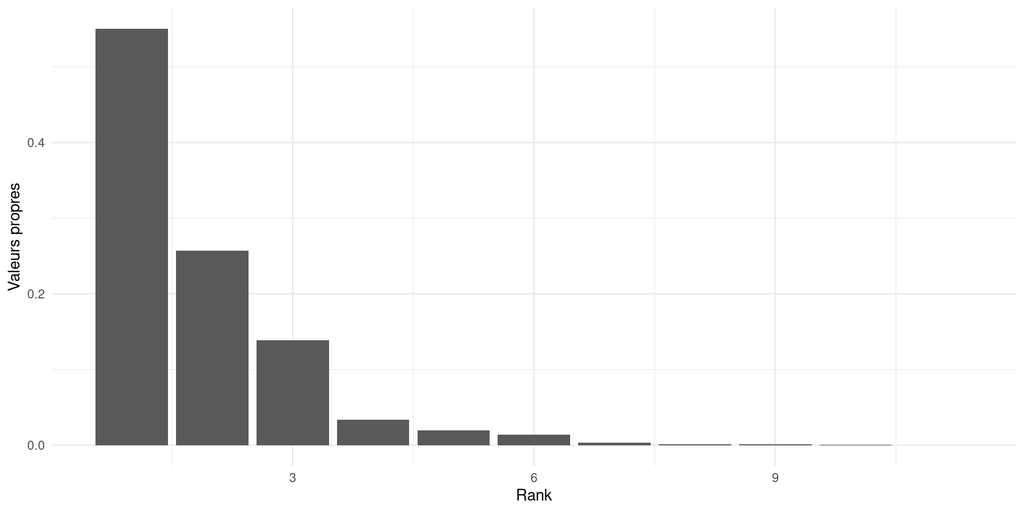

```r
tibble(eigen = res.ca$eig[,1], Rank = 1:length(res.ca$eig[,1]))  |> ggplot() +  aes(x=Rank, y =eigen ) +
  geom_bar(stat="identity") + ylab("Valeurs propres")
```

## Inertie par colonnes et lignes

```r
inertia.col <- tibble(Age= colnames(deces_dta),
                      poids = res.ca$call$marge.col,
                  inertie = res.ca$col$inertia,
                  percent.inertie = res.ca$col$inertia / sum(res.ca$col$inertia),
                  contrib_Dim1 = round(res.ca$col$contrib[,1],2),
                  contrib_Dim2 = round(res.ca$col$contrib[,2]),
                  contrib_Dim3 = round(res.ca$col$contrib[,3]))
inertia.col |>  arrange(-inertie) |> flextable()

inertia.row <- tibble(Cause= row.names(deces_dta[1:65,]),
                      poids = res.ca$call$marge.row,
                  inertie = res.ca$row$inertia,
                  percent.inertie = res.ca$row$inertia / sum(res.ca$row$inertia),
                  contrib_Dim1 = round(res.ca$row$contrib[,1],2),
                  contrib_Dim2 = round(res.ca$row$contrib[,2],2),
                  contrib_Dim3 = round(res.ca$row$contrib[,3],2))
inertia.row |>  arrange(-inertie)|> flextable()
```

| Age | poids | inertie | percent.inertie | contrib_Dim1 | contrib_Dim2 | contrib_Dim3 |
| --- | --- | --- | --- | --- | --- | --- |
| X0.1 | 0.009859542 | 0.53741393 | 0.52622173 | 97.07 | 1 | 0 |
| X15.24 | 0.011752227 | 0.12477123 | 0.12217274 | 0.24 | 33 | 22 |
| X25.34 | 0.013952165 | 0.06315096 | 0.06183577 | 0.12 | 19 | 5 |
| X85.94 | 0.218937809 | 0.05458147 | 0.05344475 | 0.45 | 10 | 16 |
| X45.54 | 0.065748560 | 0.04653089 | 0.04556184 | 0.00 | 9 | 13 |
| X35.44 | 0.025147553 | 0.04078799 | 0.03993854 | 0.02 | 12 | 0 |
| X55.64 | 0.099385776 | 0.04058194 | 0.03973677 | 0.07 | 4 | 21 |
| X95.et.plus | 0.041005637 | 0.02876157 | 0.02816258 | 0.07 | 3 | 8 |
| X75.84 | 0.318894604 | 0.02437969 | 0.02387195 | 0.66 | 5 | 1 |
| X1.4 | 0.002104453 | 0.02205803 | 0.02159865 | 0.73 | 1 | 1 |
| X65.74 | 0.190002052 | 0.02121531 | 0.02077348 | 0.31 | 0 | 11 |
| X5.14 | 0.003209622 | 0.01703599 | 0.01668119 | 0.26 | 3 | 2 |

| Cause | poids | inertie | percent.inertie | contrib_Dim1 | contrib_Dim2 | contrib_Dim3 |
| --- | --- | --- | --- | --- | --- | --- |
| Infections en période périnatale | 0.0033580492 | 0.33098142071 | 0.32408838801 | 59.10 | 1.31 | 0.31 |
| Accidents de transport | 0.0152738294 | 0.13993125830 | 0.13701704415 | 0.16 | 41.05 | 19.20 |
| Syndrome de mort subite nourrisson | 0.0008073688 | 0.08107967694 | 0.07939110825 | 14.44 | 0.34 | 0.09 |
| Malformations congénitales appareil circulatoire | 0.0017896360 | 0.06677353882 | 0.06538291035 | 11.51 | 0.04 | 0.08 |
| Suicides | 0.0192927109 | 0.05105788125 | 0.04999454771 | 0.00 | 16.25 | 0.00 |
| Autres malformations congén. et anom. chromosomiques | 0.0014398392 | 0.04171619756 | 0.04084741431 | 7.43 | 0.01 | 0.00 |
| Tumeur maligne larynx trachée bronches et poumon | 0.0478446373 | 0.02794991398 | 0.02736782792 | 0.09 | 1.24 | 16.50 |
| Maladie chronique foie | 0.0223208166 | 0.02704980631 | 0.02648646593 | 0.02 | 3.04 | 12.21 |
| Autres symptômes et états morbide mal définis | 0.0364100639 | 0.02094527691 | 0.02050906971 | 0.06 | 2.19 | 5.31 |
| Autres cardiopathies | 0.0922139962 | 0.02011812483 | 0.01969914393 | 0.23 | 4.27 | 5.07 |
| Malformations congénitales système nerveux | 0.0004774253 | 0.02002494706 | 0.01960790669 | 3.08 | 0.03 | 0.08 |
| Autres accidents | 0.0235980476 | 0.01793238593 | 0.01755892532 | 0.32 | 4.13 | 2.69 |
| Causes inconnues ou non précisées | 0.0266469520 | 0.01363483072 | 0.01335087118 | 1.53 | 1.64 | 0.00 |
| Maladies cérébrovasculaires | 0.0934808278 | 0.01221373699 | 0.01195937320 | 0.27 | 2.87 | 0.96 |
| Abus alcool et psychose alcoolique | 0.0059815251 | 0.01057807394 | 0.01035777454 | 0.00 | 1.70 | 2.80 |
| Tumeur maligne lèvre cavité buccale et pharynx | 0.0091949285 | 0.01035182865 | 0.01013624104 | 0.01 | 0.85 | 4.75 |
| Événements dont intention non déterminée | 0.0025232638 | 0.00982909296 | 0.00962439187 | 0.01 | 3.39 | 0.44 |
| Autres troubles mentaux et comportement | 0.0162334071 | 0.00864414932 | 0.00846412591 | 0.05 | 1.21 | 2.59 |
| Homicides | 0.0009349974 | 0.00638444049 | 0.00625147787 | 0.05 | 1.86 | 0.49 |
| Autres tumeurs malignes | 0.0464662489 | 0.00637852753 | 0.00624568805 | 0.07 | 0.39 | 3.18 |
| Infection à méningocoques | 0.0001389733 | 0.00630877612 | 0.00617738929 | 0.21 | 0.12 | 0.16 |
| Tumeur maligne sein | 0.0191329389 | 0.00587563051 | 0.00575326438 | 0.03 | 0.44 | 2.99 |
| Pneumonie | 0.0139861991 | 0.00543127885 | 0.00531816681 | 0.02 | 0.85 | 1.63 |
| SIDA et maladies à VIH | 0.0007648259 | 0.00536433542 | 0.00525261755 | 0.00 | 0.72 | 0.20 |
| Tumeur maligne oesophage | 0.0087609914 | 0.00525279161 | 0.00514339676 | 0.02 | 0.23 | 3.07 |
| Cardiopathies ischémiques | 0.0835210734 | 0.00517877174 | 0.00507091843 | 0.23 | 0.74 | 0.62 |
| Autres maladie appareil circulatoire | 0.0586089244 | 0.00491979494 | 0.00481733509 | 0.16 | 1.29 | 0.40 |
| Complic. de grossesse accouch. et puerpéralité | 0.0001418095 | 0.00361324099 | 0.00353799148 | 0.00 | 0.72 | 0.35 |
| Autres maladies système nerveux et organes sens | 0.0372665934 | 0.00334134362 | 0.00327175666 | 0.02 | 0.39 | 1.27 |
| Chutes accidentelles | 0.0168583143 | 0.00322024180 | 0.00315317691 | 0.03 | 0.28 | 1.30 |
| Tumeur maligne prostate | 0.0146668847 | 0.00306465747 | 0.00300083278 | 0.05 | 0.50 | 0.00 |
| Tumeur maligne foie et voies biliaires intrahépatiques | 0.0108380280 | 0.00305001252 | 0.00298649283 | 0.02 | 0.03 | 1.55 |
| Pharmacodépendance toxicomanie | 0.0002098781 | 0.00298035559 | 0.00291828658 | 0.00 | 0.64 | 0.13 |
| Intoxications accidentelles | 0.0014786005 | 0.00295261815 | 0.00289112680 | 0.00 | 0.92 | 0.21 |
| Autres maladies appareil respiratoire | 0.0251087915 | 0.00282186569 | 0.00276309740 | 0.03 | 0.71 | 0.60 |
| Tumeur maligne tissus lymphatiques et hématopoïétiques | 0.0193532163 | 0.00278386768 | 0.00272589073 | 0.01 | 0.32 | 0.09 |
| Tumeur maligne pancréas | 0.0121502387 | 0.00244592236 | 0.00239498348 | 0.03 | 0.00 | 1.30 |
| Autres maladies endocriniennes nutritionelles et métaboliques | 0.0132431173 | 0.00243320207 | 0.00238252811 | 0.00 | 0.27 | 0.78 |
| Maladies rein et uretère | 0.0129018291 | 0.00227658982 | 0.00222917747 | 0.03 | 0.54 | 0.44 |
| Méningites | 0.0005908730 | 0.00212430238 | 0.00208006157 | 0.30 | 0.06 | 0.00 |
| Tumeur maligne côlon | 0.0205661603 | 0.00210053621 | 0.00205679036 | 0.06 | 0.10 | 0.54 |
| Tumeur maligne estomac | 0.0130304030 | 0.00191841122 | 0.00187845831 | 0.03 | 0.00 | 0.79 |
| Autres maladies chroniques voies respiratoires inférieures | 0.0164083055 | 0.00179714616 | 0.00175971872 | 0.04 | 0.43 | 0.02 |
| Tumeur maligne ovaire | 0.0053566178 | 0.00167176614 | 0.00163694987 | 0.01 | 0.09 | 0.98 |
| Diabète sucré | 0.0171022267 | 0.00156347603 | 0.00153091502 | 0.05 | 0.30 | 0.00 |
| Infections peau et tissu cellulaire sous-cutané | 0.0032559463 | 0.00147454917 | 0.00144384015 | 0.01 | 0.25 | 0.45 |
| Tumeur maligne rectum et anus | 0.0087420835 | 0.00130040783 | 0.00127332548 | 0.02 | 0.00 | 0.59 |
| Tumeur maligne col utérus | 0.0014436208 | 0.00122790761 | 0.00120233516 | 0.00 | 0.16 | 0.40 |
| Tumeur maligne vessie | 0.0078694823 | 0.00110749889 | 0.00108443407 | 0.02 | 0.05 | 0.27 |
| Autres maladies appareil digestif | 0.0310874804 | 0.00106601944 | 0.00104381848 | 0.04 | 0.26 | 0.06 |
| Mélanome malin peau | 0.0020864906 | 0.00100508123 | 0.00098414937 | 0.00 | 0.20 | 0.20 |
| Autres maladies appareil génito-urinaire | 0.0041484008 | 0.00096022262 | 0.00094022498 | 0.01 | 0.22 | 0.19 |
| Tumeur maligne rein | 0.0049586058 | 0.00094275737 | 0.00092312347 | 0.01 | 0.01 | 0.50 |
| Tumeur maligne autres parties utérus | 0.0049765683 | 0.00082199087 | 0.00080487205 | 0.01 | 0.01 | 0.50 |
| Maladies sang et organes hématopoïétiques | 0.0042467221 | 0.00065320327 | 0.00063959963 | 0.00 | 0.00 | 0.09 |
| Autres maladies infectieuses et parasitaires | 0.0111651353 | 0.00055792744 | 0.00054630802 | 0.01 | 0.09 | 0.10 |
| Hépatites virales | 0.0010096837 | 0.00038053701 | 0.00037261193 | 0.00 | 0.08 | 0.07 |
| Autres tumeurs | 0.0100174237 | 0.00035401791 | 0.00034664512 | 0.01 | 0.02 | 0.01 |
| Autres maladies système ostéo-articulaire muscles et tissu conjonctif | 0.0037399894 | 0.00035104874 | 0.00034373779 | 0.01 | 0.06 | 0.10 |
| Grippe | 0.0011146227 | 0.00029929342 | 0.00029306033 | 0.00 | 0.04 | 0.12 |
| Tuberculose | 0.0026490016 | 0.00026762638 | 0.00026205278 | 0.00 | 0.01 | 0.13 |
| Arthrite rhumatoïde et ostéoarthrite | 0.0012167256 | 0.00017159606 | 0.00016802240 | 0.00 | 0.03 | 0.01 |
| Ulcère gastro-duodénal | 0.0028182276 | 0.00014973131 | 0.00014661300 | 0.01 | 0.01 | 0.04 |
| Autres causes externes de blessure et empoisonnement | 0.0026045680 | 0.00006473676 | 0.00006338855 | 0.00 | 0.01 | 0.00 |
| Asthme | 0.0023748366 | 0.00004679243 | 0.00004581793 | 0.00 | 0.00 | 0.01 |

## Visualisation des résultats : axes 1 et 2

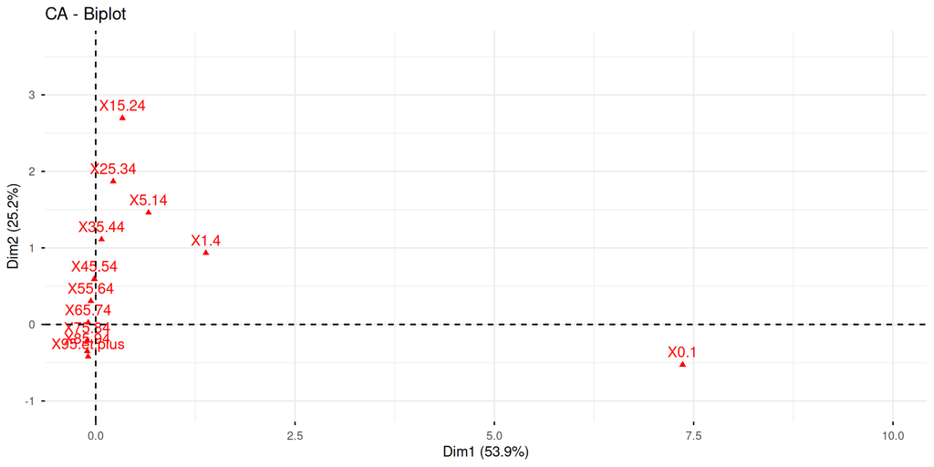

```r
fviz_ca(res.ca, axes = 1:2, invisible = c("row", "row.sup"))
```

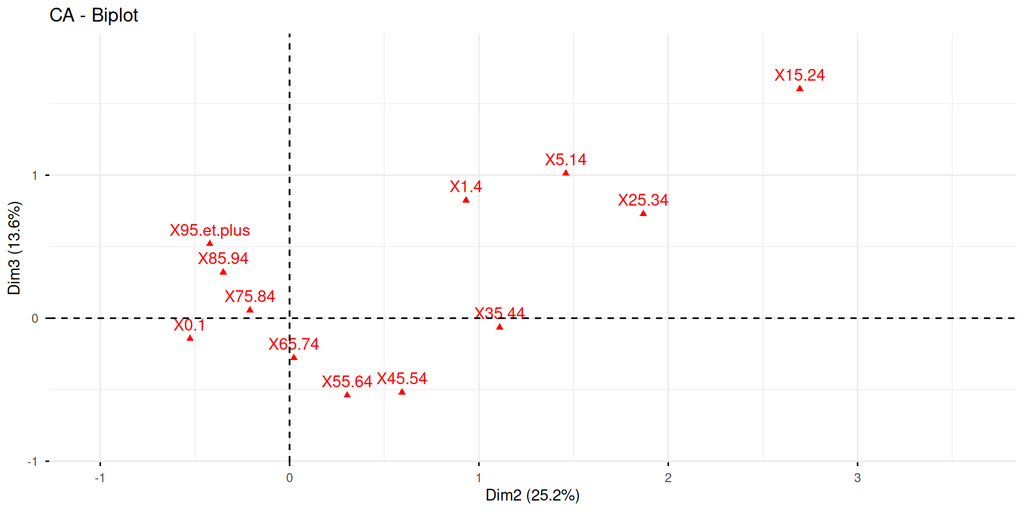

```r
fviz_ca(res.ca, axes = 2:3, invisible = c("row", "row.sup"))
```

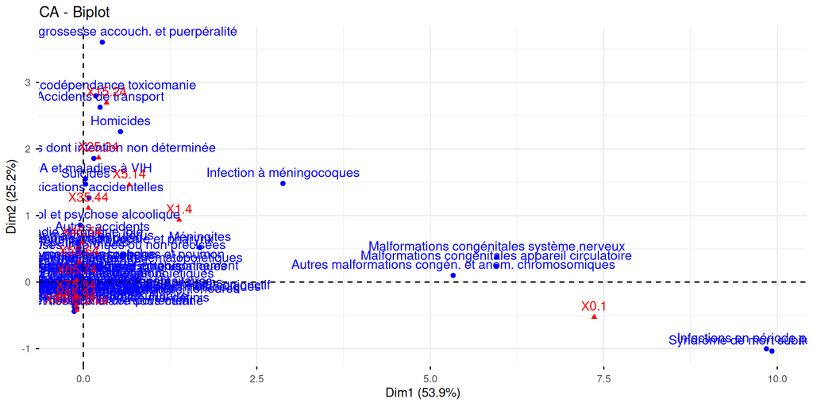

```r
fviz_ca(res.ca, axes = 1:2, invisible = c("row.sup"))
```

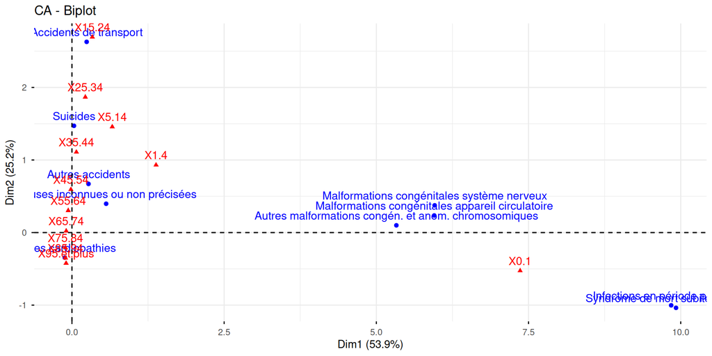

```r
fviz_ca(res.ca, axes = 1:2, invisible = c("row.sup"), select.row =  list(contrib = 10))
```

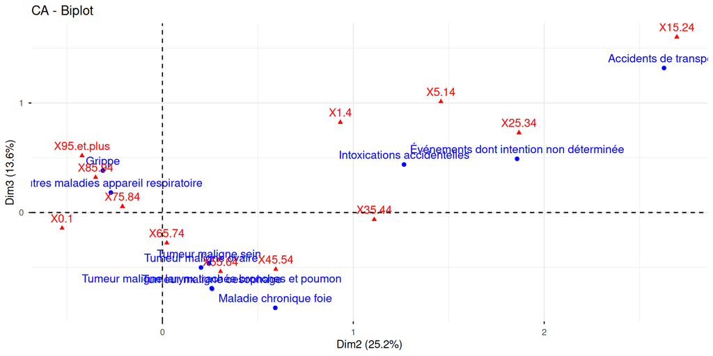

```r
fviz_ca(res.ca, axes = 2:3, invisible = c("row.sup"), select.row =  list(cos2 = 10))
```

## Visualisation des résultats : axes 2 et 3

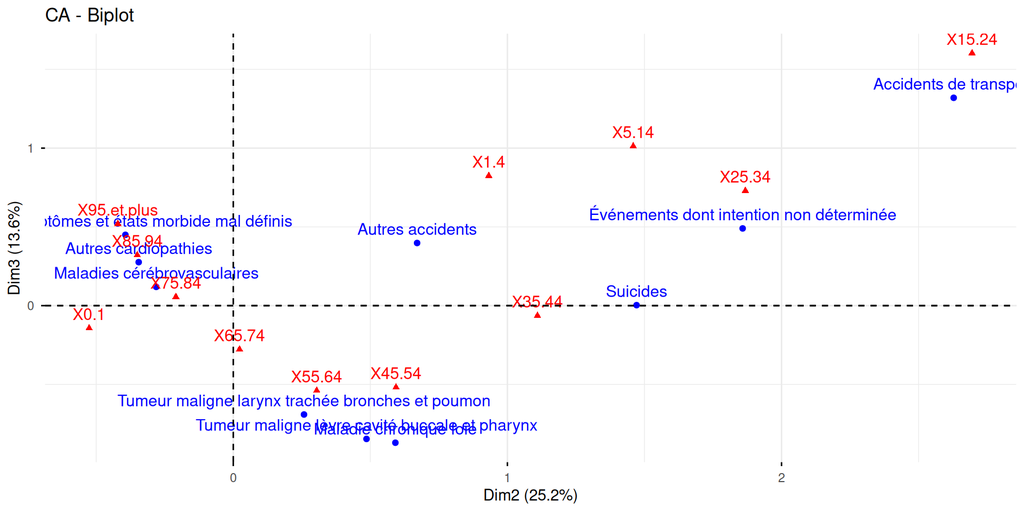

```r
fviz_ca(res.ca, axes = 2:3, invisible = c("row.sup"), select.row =  list(contrib = 10))
```

## Distance et résumé des contributions

### Distances entre colonnes

```r
round(dist(res.ca$col$coord), 3)
```

```
             X0.1  X1.4 X5.14 X15.24 X25.34 X35.44 X45.54 X55.64 X65.74 X75.84
X1.4        6.818
X5.14       7.221 2.069
X15.24      7.965 3.656 2.008
X25.34      7.611 3.263 1.874  1.840
X35.44      7.495 3.241 2.118  2.694  1.250
X45.54      7.480 3.322 2.352  3.166  1.944  0.874
X55.64      7.483 3.354 2.428  3.329  2.171  1.175  0.412
X65.74      7.480 3.346 2.428  3.374  2.249  1.343  0.767  0.445
X75.84      7.480 3.342 2.445  3.410  2.312  1.496  1.073  0.827  0.422
X85.94      7.486 3.351 2.485  3.449  2.373  1.619  1.282  1.094  0.754  0.380
X95.et.plus 7.505 3.390 2.562  3.508  2.463  1.766  1.491  1.355  1.098  0.807
            X85.94
X1.4
X5.14
X15.24
X25.34
X35.44
X45.54
X55.64
X65.74
X75.84
X85.94
X95.et.plus  0.474
```

```r
round(dist(res.ca$col$coord), 3)
```

[output not shown]

## Résumé des contributions (axes 2 à 5)

```r
round(data.frame(CTR = res.ca$col$contrib[,2:5],
                 CO2 = res.ca$col$cos2[,2:5]), 3)
```

```
            CTR.Dim.2 CTR.Dim.3 CTR.Dim.4 CTR.Dim.5 CO2.Dim.2 CO2.Dim.3
X0.1            1.060     0.146     0.015     0.599     0.005     0.000
X1.4            0.711     1.031     2.089    58.057     0.083     0.065
X5.14           2.659     2.375     4.075    15.458     0.401     0.193
X15.24         33.216    21.793    13.518     0.920     0.684     0.242
X25.34         18.946     5.357     4.207     6.381     0.771     0.118
X35.44         12.049     0.074    19.113     1.596     0.759     0.003
X45.54          9.017    12.762    11.460     2.453     0.498     0.380
X55.64          3.585    20.883     0.002     2.923     0.227     0.713
X65.74          0.038    10.562    11.896     0.471     0.005     0.690
X75.84          5.439     0.719     9.790     5.097     0.573     0.041
X85.94         10.447    16.309     6.272     0.298     0.492     0.414
X95.et.plus     2.832     7.988    17.564     5.747     0.253     0.385
            CO2.Dim.4 CO2.Dim.5
X0.1            0.000     0.000
X1.4            0.032     0.523
X5.14           0.081     0.180
X15.24          0.037     0.001
X25.34          0.023     0.020
X35.44          0.159     0.008
X45.54          0.083     0.010
X55.64          0.000     0.014
X65.74          0.190     0.004
X75.84          0.136     0.042
X85.94          0.039     0.001
X95.et.plus     0.207     0.040
```

## Résultats supplémentaires

### Suppression et ajustement des éléments supplémentaires

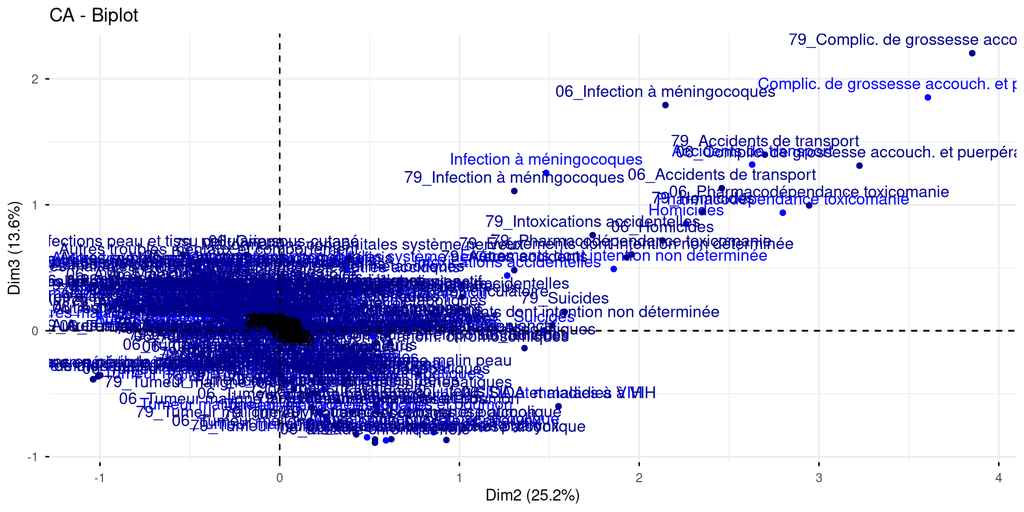

```r
#|

row_sup =  res.ca$row.sup$coord[, 1:3] |> as.data.frame() |> rownames_to_column()

row_annee <- row_sup |> filter(str_detect(rowname, pattern = "^[12]"))

annees = deces_dta |> rownames_to_column("Cause") |> filter(str_detect(Cause, pattern = "^[12]")) |> pull(Cause) |> as.list()

# fviz_ca(res.ca, invisible = c( "col"), select.row=  list(contrib = 10),  axes = 2:3) +
# geom_point(data = row_annee, aes(x=`Dim 2`, y = `Dim 3`)) +
# geom_text(data = row_annee, aes(x=`Dim 2`, y = `Dim 3`, label = rowname))

fviz_ca(res.ca, invisible = c( "col"), axes = 2:3) +
geom_point(data = row_annee, aes(x=`Dim 2`, y = `Dim 3`)) +
geom_text(data = row_annee, aes(x=`Dim 2`, y = `Dim 3`, label = rowname))
```

# Bilan

## Ce que vous pensez devoir retenir

pour des données qualitatives, avec seulement deux variables qualitatives

Le tableau de contingence est à la base de la méthode

On commence par un test du chi2 qui teste l’independance

Les notions de profils lignes et profils colonnes

On fait deux ACPS : * une ACP sur les profils lignes affcetés du poids de sa marge avec la métrique 1/ marge de la colonne * une ACP sur les profils colonnes affcetés du poids de leur marge avec la métrique 1/ marge de la ligne

la métrique est choisi pour que l’inertie totale soit le coefficient phi du test de chi2 (chi2/n)

C’est une mesure d’écart à l’independance

Une des forces de l’ACP est la représentation jointe de slignes et des colonnes grâce aux relations barycenytriques

les profils lignes ayant de svaleur positives sur un axe sont associés préférentiellement aux colonnes ayant des valeurs, tandis qu’ils s’associent moins qu’attendu avec les colonnes qui ont des valeurs négatives

Les contributions, des lignes/ et des colonnes ssont intéressantes. Il faut vérifier la qualité d ela représentaion